# Session 5 — More Groups, Repeated Measures, Correlation and Reporting

One-way and Welch ANOVA · Kruskal–Wallis · repeated measures and sphericity · Friedman · post hoc tests · Pearson and Spearman · multiple testing · Lab 5

Community Medicine Workshop

## Where we are

- Session 4: two groups, or two measurements on the same people
- Today: **three or more** groups or time points, the **relationship** between two numbers, and putting it all into **words**
- By the end you can:
  - run ANOVA or Kruskal–Wallis, and their **post hoc** tests, only when they are warranted
  - check **sphericity** for repeated measures and use **paired** post hoc tests
  - read **r**, its CI and **r²**, and choose Pearson or Spearman
  - control for **multiple testing**, and write a results paragraph

# Topic 1 — Three or more independent groups

## One-way ANOVA: BMI by wealth index

```r
p |> group_by(wealth_index_of_participants) |> summarise(n = n(), mean = mean(bmi), sd = sd(bmi))
```

```
# A tibble: 5 × 4
  wealth_index_of_participants     n  mean    sd
  <fct>                        <int> <dbl> <dbl>
1 poorest                         76  21.3  3.34
2 poorer                         113  23.3  4.42
3 middle                         139  23.2  3.84
4 richer                         158  24.0  3.53
5 richest                        145  24.9  3.85
```

```r
a_b <- aov(bmi ~ wealth_index_of_participants, data = p)
summary(a_b)
```

```
                              Df Sum Sq Mean Sq F value   Pr(>F)
wealth_index_of_participants   4    718  179.40   12.28 1.28e-09 ***
Residuals                    626   9144   14.61
---
Signif. codes:  0 '***' 0.001 '**' 0.01 '*' 0.05 '.' 0.1 ' ' 1
```

## Check the assumptions on the residuals

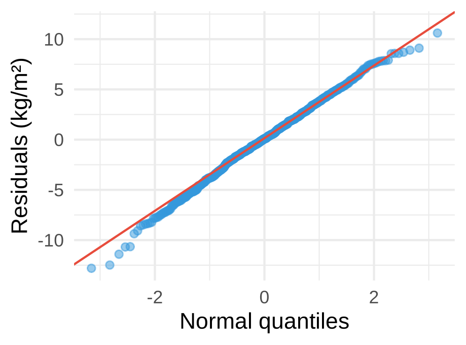

```r
leveneTest(bmi ~ wealth_index_of_participants, data = p)
```

```
Levene's Test for Homogeneity of Variance (center = median)
       Df F value  Pr(>F)
group   4  2.6111 0.03456 *
      626
---
Signif. codes:  0 '***' 0.001 '**' 0.01 '*' 0.05 '.' 0.1 ' ' 1
```

```r
oneway.test(bmi ~ wealth_index_of_participants, data = p)$p.value   # Welch ANOVA
```

```
[1] 1.324603e-10
```

- Residuals on the line; Levene p = 0.035, but the SDs differ little (largest under 1.5 × smallest) and **Welch ANOVA** agrees (p < 0.001): the conclusion does not depend on the choice

## Significant: now how big, and where?

“Mean BMI rose with household wealth, from 21.3 kg/m² in the poorest to 24.9 kg/m² in the richest group (one-way ANOVA, F(4, 626) = 12.3, p < 0.001; η² = 0.07). Richest vs poorest: 3.6 kg/m² (95% CI 2.1 to 5.1, Tukey).”

- The F-test says only “the means are not all equal”; **Tukey** gives each pair’s difference with a CI adjusted for 10 comparisons
- η² = 0.07: wealth explains about **7%** of the variation in BMI, a **medium** effect (0.01 small, 0.06 medium, 0.14 large); most variation is between people within a group
- The groups are **ordered**: a trend test or regression with wealth as a score (Regression track) uses that order and asks one question instead of 10

## Post hoc tests: when and which

| After | Post hoc | R |
| --- | --- | --- |
| One-way ANOVA, equal SDs | **Tukey HSD** | `TukeyHSD(aov(...))` |
| Welch ANOVA, unequal SDs | **Games–Howell** | `rstatix::games_howell_test()` |
| Kruskal–Wallis | **Dunn** with Holm adjustment | `rstatix::dunn_test(..., p.adjust.method = "holm")` |

Run post hoc tests to answer a question you **planned**, or after a clear overall result. Hunting through every pair after a non-significant overall test produces false findings.

## Kruskal–Wallis: systolic pressure by marital status

```r
p |> group_by(marital_status_of_participants) |>
  summarise(median = median(sbp_presentation), q1 = quantile(sbp_presentation, .25), q3 = quantile(sbp_presentation, .75))
```

```
# A tibble: 3 × 4
  marital_status_of_participants median    q1    q3
  <fct>                           <dbl> <dbl> <dbl>
1 never married                    124   108    133
2 currently married                127   113    142
3 formerly/ever married            136.  120.   151
```

```r
kruskal.test(sbp_presentation ~ marital_status_of_participants, data = p)
```

```
    Kruskal-Wallis rank sum test

data:  sbp_presentation by marital_status_of_participants
Kruskal-Wallis chi-squared = 9.7591, df = 2, p-value = 0.0076
```

- For skewed outcomes or outliers (SBP at presentation is right-skewed); compares the **distributions**, through ranks
- p = 0.008: a difference somewhere. **Dunn** (Holm-adjusted) shows where: formerly married vs never married p = 0.006, vs currently married p = 0.026

## Before you explain it: who is in each group?

```r
dunn_test(p, sbp_presentation ~ marital_status_of_participants, p.adjust.method = "holm") |>
  select(group1, group2, p.adj)
```

```
# A tibble: 3 × 3
  group1            group2                  p.adj
  <chr>             <chr>                   <dbl>
1 never married     currently married     0.0905
2 never married     formerly/ever married 0.00641
3 currently married formerly/ever married 0.0257
```

Formerly married adults (mostly widowed) are **older**: mean age 55.0 vs 43.2 (currently) and 34.2 years (never married), and SBP rises with age. The test shows a **difference**, not its **cause**: separating marital status from age needs **regression** (Regression track).

# Topic 2 — Repeated measurements

## Repeated-measures ANOVA: fasting glucose at 0, 3 and 6 months

```r
fbs_long <- p |> select(s_no, fbs_presentation, fbs_3_months, fbs_6_months) |>
  pivot_longer(-s_no, names_to = "time", values_to = "fbs")
anova_test(data = fbs_long, dv = fbs, wid = s_no, within = time)
```

```
ANOVA Table (type III tests)

$ANOVA
  Effect DFn  DFd       F         p p<.05   ges
1   time   2 1260 659.239 1.19e-196     * 0.078

$`Mauchly's Test for Sphericity`
  Effect     W        p p<.05
1   time 0.755 4.12e-39     *

$`Sphericity Corrections`
  Effect   GGe        DF[GG]     p[GG] p[GG]<.05   HFe        DF[HF]     p[HF]
1   time 0.803 1.61, 1012.05 1.23e-158         * 0.805 1.61, 1014.24 5.67e-159
  p[HF]<.05
1         *
```

## Sphericity, and the correction

- **Sphericity**: the variance of the differences is the same for every pair of time points (0–3, 0–6, 3–6)
- **Mauchly’s test** checks it; when violated, use the **Greenhouse–Geisser** corrected p-value (`p[GG]`), which `anova_test()` prints alongside
- Here Mauchly p < 0.001: sphericity is violated (the 0–6 month changes vary more than the 0–3), so report the **GG-corrected** result, ε = 0.80
- **ges** (generalised η²) = 0.08: a **modest** share of the total variation, because people differ from **each other** far more than from one visit to the next. The F-test is huge because each person is compared with themselves

“Mean fasting glucose fell from 109.0 mg/dL at presentation to 102.8 at 3 and 98.6 at 6 months (repeated-measures ANOVA with Greenhouse–Geisser correction, F(1.61, 1012) = 659, p < 0.001; generalised η² = 0.08).”

## Post hoc for repeated measures must be **paired**

```r
pairwise.t.test(fbs_long$fbs, fbs_long$time, paired = TRUE, p.adjust.method = "bonferroni")
```

```
    Pairwise comparisons using paired t tests

data:  fbs_long$fbs and fbs_long$time

                 fbs_3_months fbs_6_months
fbs_6_months     <2e-16       -
fbs_presentation <2e-16       <2e-16

P value adjustment method: bonferroni
```

Without `paired = TRUE`, `pairwise.t.test()` treats the three visits as **independent groups** of different people and pools their SD: the wrong test for repeated measurements. Because the visits are strongly correlated it throws away most of the information: its p-values are many orders of magnitude larger, and with a smaller change it would miss it altogether.

## Friedman: systolic pressure at 0, 3 and 6 months

```r
sbp_long <- p |> select(s_no, sbp_presentation, sbp_3_months, sbp_6_months) |>
  pivot_longer(-s_no, names_to = "time", values_to = "sbp")
friedman.test(sbp ~ time | s_no, data = sbp_long)
```

```
    Friedman rank sum test

data:  sbp and time and s_no
Friedman chi-squared = 337.15, df = 2, p-value < 2.2e-16
```

```r
pairwise.wilcox.test(sbp_long$sbp, sbp_long$time, paired = TRUE, p.adjust.method = "holm")$p.value
```

```
                 sbp_3_months sbp_6_months
sbp_6_months     5.051829e-10           NA
sbp_presentation 1.779175e-43 5.850735e-66
```

- The rank-based partner of repeated-measures ANOVA; every person needs **all** time points
- Medians 127 → 123 → 120 mmHg; effect size **Kendall’s W** = 0.27 (0.1 small, 0.3 moderate, 0.5 large)

# Topic 3 — Two numbers together: correlation

## Plot first, then r

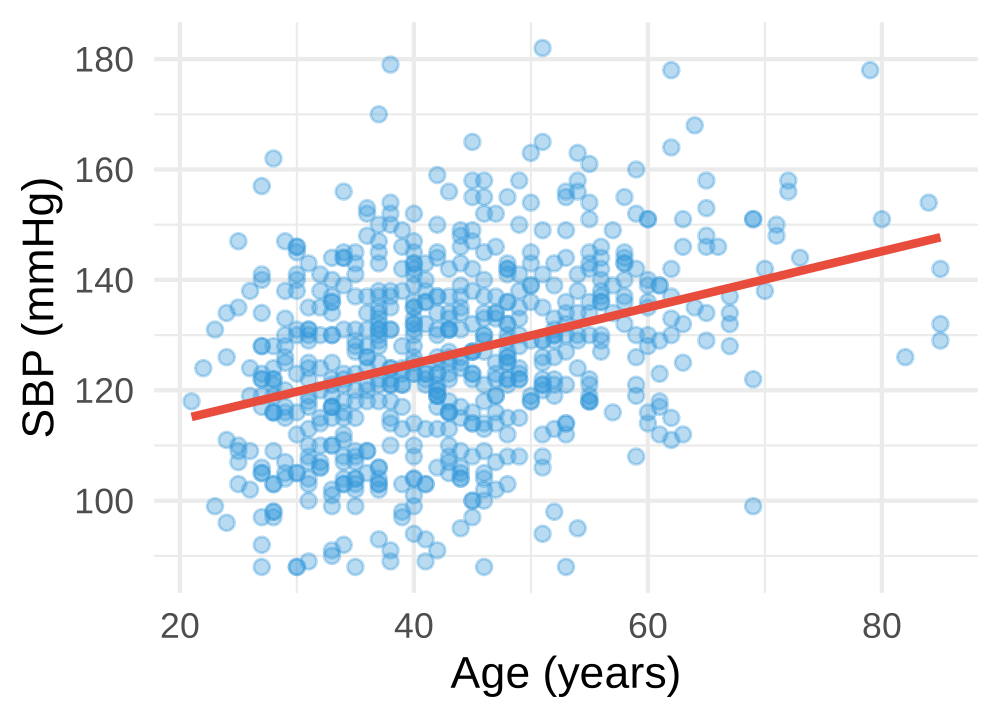

```r
cor.test(p$age_of_participants, p$sbp_in_mm_hg)
```

```
    Pearson's product-moment correlation

data:  p$age_of_participants and p$sbp_in_mm_hg
t = 9.2256, df = 629, p-value < 2.2e-16
alternative hypothesis: true correlation is not equal to 0
95 percent confidence interval:
 0.2745788 0.4121774
sample estimates:
     cor
0.345232
```

## Reading r

“Systolic pressure rose with age (Pearson r = 0.35, 95% CI 0.27 to 0.41; p < 0.001).”

- **r²** = 0.12: age accounts for about **12%** of the variation in SBP. A **moderate** association: highly significant, yet most of the variation lies elsewhere
- Correlation measures **linear association** only; it is not agreement (use Bland–Altman for that) and not causation
- To estimate *how much* SBP changes per year of age, and to adjust for other factors: **regression** (Regression track)

## Pearson or Spearman?

|  | Pearson r | Spearman ρ |
| --- | --- | --- |
| Measures | **linear** association | **monotonic** association (through ranks) |
| Needs | roughly normal pairs, no extreme outliers | ordinal or numeric data, any shape |
| Use for | age and SBP | glucose (skewed, outliers up to 291 mg/dL), ordinal scores |

```r
cor.test(p$age_of_participants, p$glucose_level_mg_d_l, method = "spearman", exact = FALSE)$estimate
```

```
     rho
0.264975
```

# Topic 4 — Many tests, and the write-up

## Multiple testing

- At p < 0.05, **1 in 20** tests of a true null hypothesis comes out “significant” by chance
- 20 independent comparisons → about a **64%** chance of at least one false positive
- **Bonferroni**: multiply each p by the number of tests (simple, strict). **Holm**: the same idea step by step, never worse, usually better
- `p.adjust(c(0.01, 0.02, 0.04), method = "holm")` → 0.03, 0.04, 0.04
- Decide the **main** comparisons in advance; label the rest as **exploratory**

## A results paragraph

“Of 631 adults, 27 (4.3%) reported diabetes. They were older (mean difference 10.9 years, 95% CI 6.4 to 15.4; Welch t-test) and more often hypertensive (odds ratio 6.3, 95% CI 2.5 to 15.6; Fisher’s exact test). Mean fasting glucose fell over six months (Topic 2).”

- **Every** claim: the numbers, the **effect with its CI**, the **test**; p-values to 2–3 decimals, “p < 0.001” below that
- Methods: how assumptions were checked and what was done when they failed (Session 2)

## Reporting checklist

|  | Write down |
| --- | --- |
| Descriptives | n for every group; mean (SD) or median (IQR); n (%) |
| Data checks | what was excluded and why; sensitivity analysis |
| Assumptions | how checked (plots, tests); what was done if not met |
| Each result | effect size **with 95% CI**, the test, the exact p |
| Many tests | which were planned; the adjustment method |
| Interpretation | size and importance, not only “significant”; association, not cause |

Building Table 1 with **gtsummary**: which of these tests it runs, which it cannot, and a pipeline that picks each test

## 🔧 Switch to R — Lab 5

**File:** `stats-workshop/labs/lab5_more_groups.R`

- one-way ANOVA with residual checks, Welch ANOVA and Tukey
- Kruskal–Wallis, and when not to run post hoc tests
- repeated-measures ANOVA with sphericity, and **paired** post hoc tests
- Friedman with Kendall’s W
- Pearson and Spearman, r², and a Holm adjustment

**Time:** 40 minutes · answer the Q questions in the comments

## Self-check quiz (1/5)

A one-way ANOVA gives p = 0.056 and eta squared = 0.009. What is the best reading?

- A trend that would be significant with a few more people
- Weak evidence, and the grouping explains under 1% of variation
- Clear evidence of a difference, since p is close to 0.05
- The groups are now proven equal, so no differences are reported

## Self-check quiz (2/5)

Fasting glucose was measured in the same adults at 0, 3 and 6 months. Which post hoc comparison is right after a repeated-measures ANOVA?

- pairwise.t.test() with the default settings on the long data
- pairwise.t.test() with paired = TRUE and an adjustment
- Three separate Welch t-tests with no multiplicity adjustment
- A Tukey HSD test on the aov() of glucose by time point only

## Self-check quiz (3/5)

Mauchly’s test for a repeated-measures ANOVA gives p = 0.002. What should you report?

- The uncorrected F-test, since sphericity is a minor point
- A Kruskal-Wallis test in place of the repeated measures model
- The Greenhouse-Geisser corrected p-value for the time effect
- Nothing, as the analysis cannot be done with these data

## Self-check quiz (4/5)

Age and systolic pressure: r = 0.35, 95% CI 0.27 to 0.41, p < 0.001. What is the right reading?

- A strong link, since the p-value is so very small
- Age explains about 12% of the variation in SBP
- Getting older causes a rise in systolic pressure
- SBP and age agree closely when measured in adults

## Self-check quiz (5/5)

With 20 independent tests at the 5% level and every null hypothesis true, the chance of at least one false positive is about what percent? (number only)

## Score and take-home

**Your score:**

- ≥ 3 groups: ANOVA (Welch if SDs differ) or **Kruskal–Wallis**; post hoc only when warranted
- Repeated measures: check **sphericity**; post hoc tests must be **paired**
- Correlation: **plot**, then r with its CI; r² for strength; not cause, not agreement
- Plan the main tests; **adjust** the rest; report effect sizes with CIs, in sentences

**Next:** the **Regression** track: the same questions with several factors at once